# EDA SIP

## O que são os dados

```
## Observations: 12,299
## Variables: 17
## $ TaskNumber           <chr> "1735", "1742", "1971", "2134", "2251", "...
## $ Summary              <chr> "Flag RI on SCM Message Summary screen us...
## $ Priority             <dbl> 1, 1, 2, 5, 10, 1, 5, 5, 6, 5, 2, 1, 3, 1...
## $ RaisedByID           <chr> "58", "58", "7", "50", "46", "13", "13", ...
## $ AssignedToID         <chr> "58", "42", "58", "42", "13", "13", "13",...
## $ AuthorisedByID       <chr> "6", "6", "6", "6", "6", "58", "6", "6", ...
## $ StatusCode           <chr> "FINISHED", "FINISHED", "FINISHED", "FINI...
## $ ProjectCode          <chr> "PC2", "PC2", "PC2", "PC2", "PC2", "PC9",...
## $ ProjectBreakdownCode <chr> "PBC42", "PBC21", "PBC75", "PBC42", "PBC2...
## $ Category             <chr> "Development", "Development", "Operationa...
## $ SubCategory          <chr> "Enhancement", "Enhancement", "In House S...
## $ HoursEstimate        <dbl> 14.00, 7.00, 0.70, 0.70, 3.50, 7.00, 7.00...
## $ HoursActual          <dbl> 1.75, 7.00, 0.70, 0.70, 3.50, 7.00, 7.00,...
## $ DeveloperID          <chr> "58", "42", "58", "42", "13", "13", "43",...
## $ DeveloperHoursActual <dbl> 1.75, 7.00, 0.70, 0.70, 3.50, 7.00, 7.00,...
## $ TaskPerformance      <dbl> 12.25, 0.00, 0.00, 0.00, 0.00, 0.00, 0.00...
## $ DeveloperPerformance <dbl> 12.25, 0.00, 0.00, 0.00, 0.00, 0.00, NA, ...
```

## Entendendo os dados

```
## # A tibble: 12,299 x 4
##    ProjectCode TaskNumber HoursEstimate HoursActual
##    <chr>       <chr>              <dbl>       <dbl>
##  1 PC2         1735               14           1.75
##  2 PC2         1742                7           7
##  3 PC2         1971                0.7         0.7
##  4 PC2         2134                0.7         0.7
##  5 PC2         2251                3.5         3.5
##  6 PC9         2283                7           7
##  7 PC2         2400                7           7
##  8 PC2         2451                7           7
##  9 PC2         2475                1.4         1.4
## 10 PC9         2499                1.75        1.75
## # ... with 12,289 more rows
```

Temos 20 projetos, com 12299 estimativas_raw. Não há apenas uma estimativa por tarefa, já que há apenas 10266 valores distintos de `TaskNumber`.

```
## # A tibble: 1,384 x 2
## # Groups:   TaskNumber [1,384]
##    TaskNumber     n
##    <chr>      <int>
##  1 10605          8
##  2 6889           8
##  3 10089          7
##  4 10974          7
##  5 11056          7
##  6 11270          7
##  7 13124          7
##  8 13190          7
##  9 13253          7
## 10 3812           7
## # ... with 1,374 more rows
```

### 1 estimativa por task

Para nossa análise, usaremos uma estimativa por task. Caso haja mais de uma usaremos a média das estimativas_raw:

## Qual a relação entre as estimativas e horas reais tomadas na empresa como um todo e em diferentes categorias de tarefa?

Vamos ver primeiramente como são distribuídos os dados das estimativas e horas gastas reais.

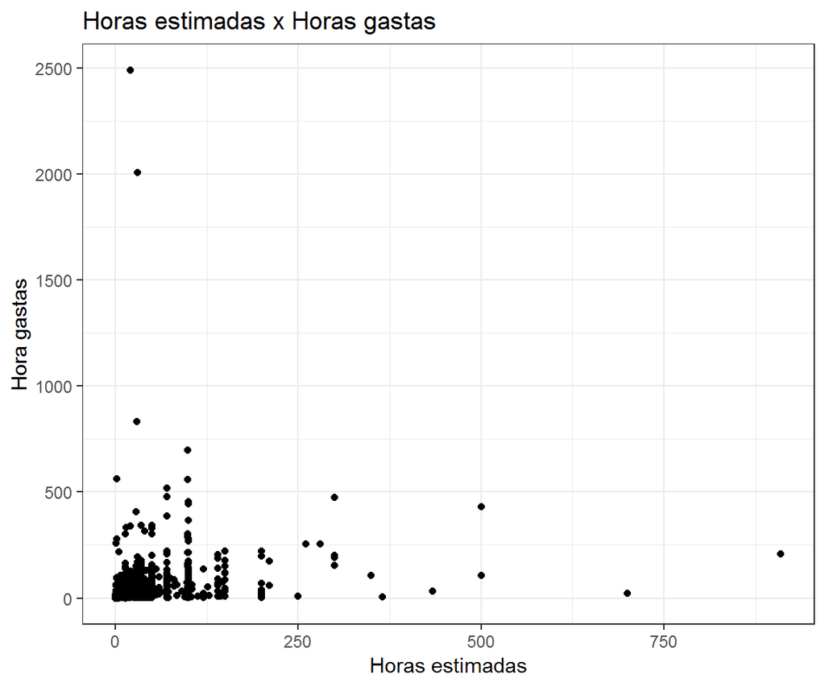

Podemos ver que os dados são muito concentrados a esquerda e abaixo e existem alguns picos para as duas variáveis, tornando difícil fazer qualquer observação sobre a correlação.

Para melhorar a análise, vamos trabalhar com logs. Assim, a medida da correlação não será tão influenciada pelos outliers.

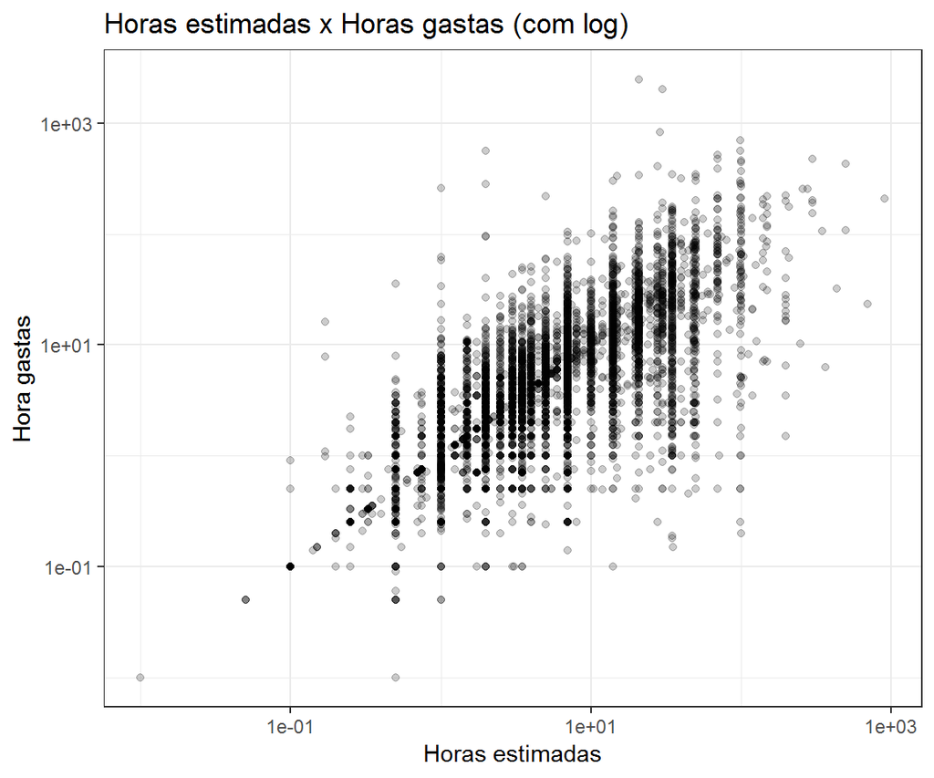

No primeiro gráfico é difícil notar qualquer relação entre os dados, mas no segundo podemos ver a relação entre eles mais claramente.

Agora vamos analisar, também aplicando o log na base 10 do valor original, qual a relação entre as estimativas e horas reais gastas na empresa para diferentes categorias de tarefa.

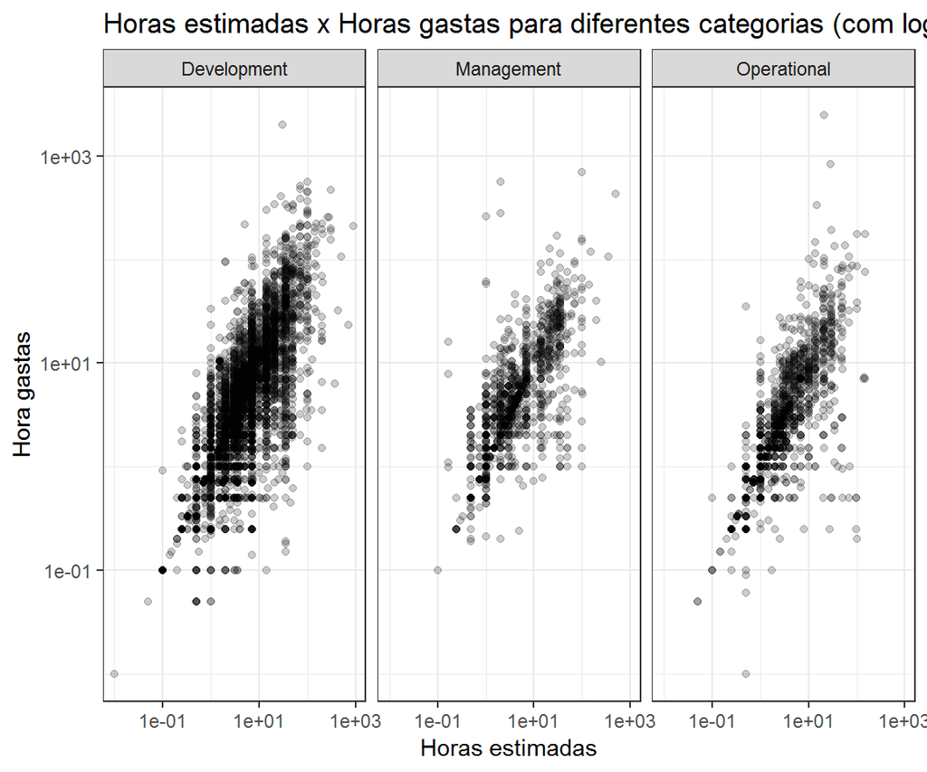

Como um resumo das visualizações acima, vejamos os valores de correlação para os dados de todas as categorias:

```
## # A tibble: 1 x 3
##   pearson spearman kendall
##     <dbl>    <dbl>   <dbl>
## 1   0.316    0.826   0.696
```

Se removermos os valores extremos, os valores de correlação tendem a mudar para ‘pearson’ que é mais influenciada pelos outliers:

```
## # A tibble: 1 x 3
##   pearson spearman kendall
##     <dbl>    <dbl>   <dbl>
## 1   0.488    0.826   0.696
```

E para as categorias separadamente:

```
## # A tibble: 3 x 4
##   Category    pearson spearman kendall
##   <chr>         <dbl>    <dbl>   <dbl>
## 1 Development   0.486    0.834   0.700
## 2 Management    0.493    0.752   0.634
## 3 Operational   0.487    0.841   0.729
```

## Equipes com mais desenvolvedores produzem estimativas com mais ou menos erro que equipes menores?

Vamos analisar a relação entre o número de desenvolvedores e erro nas estimativas dos projetos.

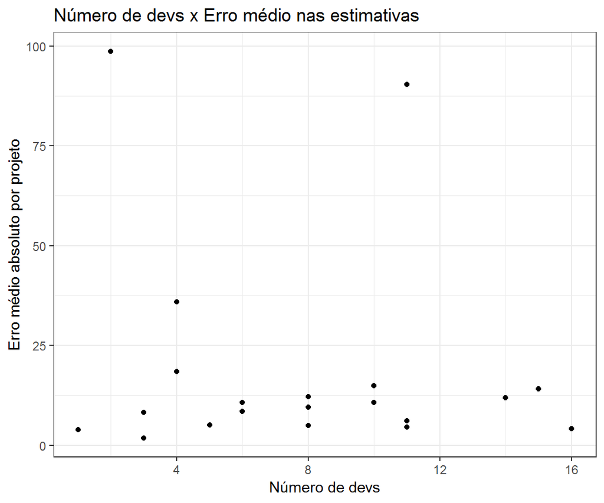

Mais uma vez, os dados “crus” não nos dizem muita coisa a respeito da correlação entre as variáveis. Vamos analisar aplicando o log de base 10.

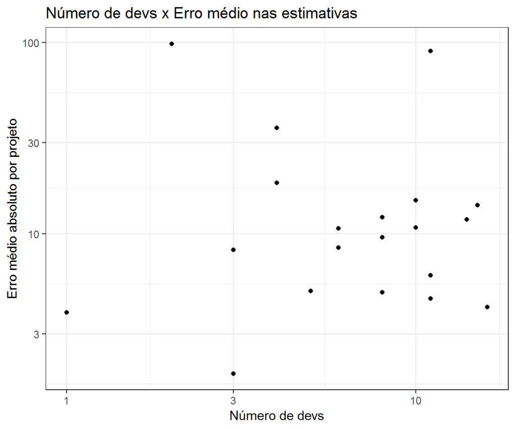

A visualização acima nos leva a crer que não há uma correlação significativa entre o número de desenvolvedores e erro nas estimativas dos projetos. Vamos confirmar a intuição a partir dos valores sumarizados pelos métodos de correlação pearson, spearman e kendall.

```
## # A tibble: 1 x 3
##   pearson spearman kendall
##     <dbl>    <dbl>   <dbl>
## 1  -0.137   0.0438  0.0324
```